# Biostat M280 Homework 2

5.Compare and contrast geom_violin() with a facetted geom_histogram(), or a coloured geom_freqpoly(). What are the pros and cons of each method?

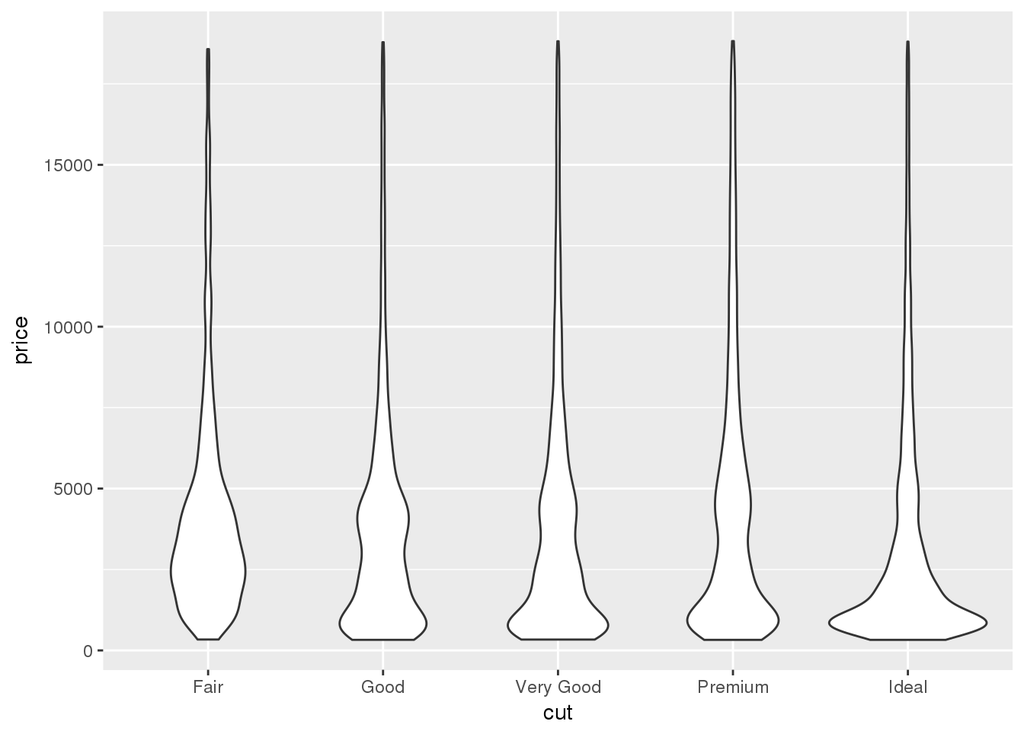

```r
diamonds %>%
  ggplot() +
  geom_violin(mapping = aes(x = cut, y = price))
```

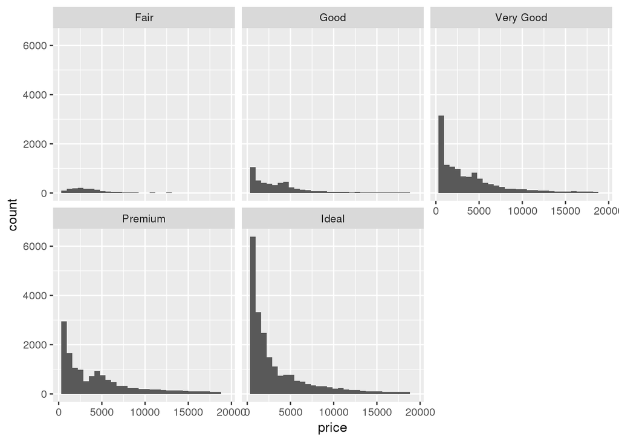

```r
diamonds %>%
  ggplot() +
  geom_histogram(mapping = aes(x = price)) +
  facet_wrap(~cut)
```

Violin plot shows multimodal data, and is better in discribing a distribution. However, in violin plot, we cannot find the number of observations count. While in histogram, we can see the number of observations, but the bin size may change the shape of the distribution.

6.If you have a small dataset, it’s sometimes useful to use geom_jitter() to see the relationship between a continuous and categorical variable. The ggbeeswarm package provides a number of methods similar to geom_jitter(). List them and briefly describe what each one does.

```r
if (!require("ggbeeswarm"))
     install.packages("ggbeeswarm", repos='http://cran.us.r-project.org')
```

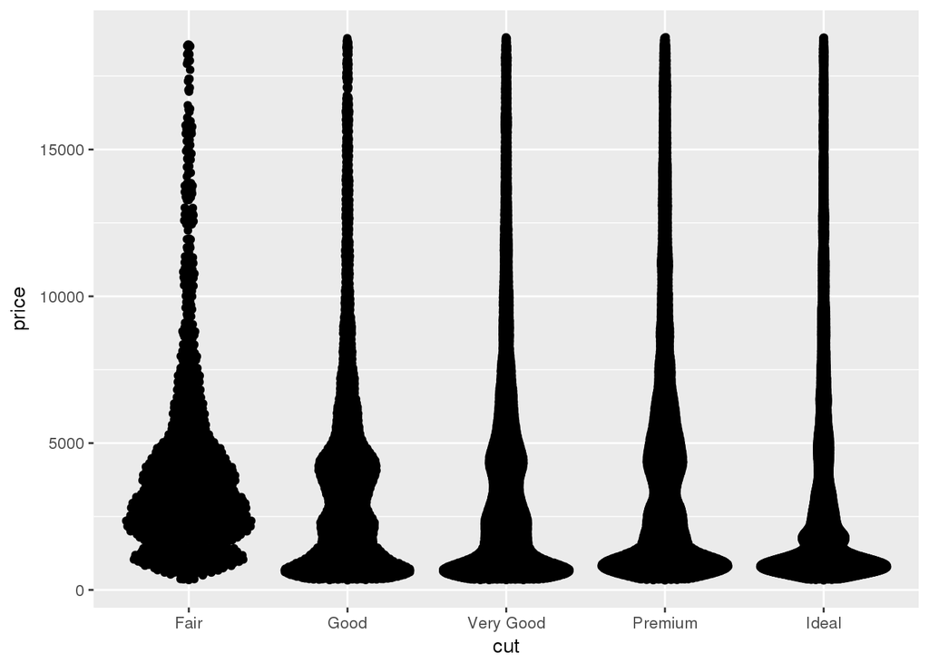

```r
library(ggbeeswarm)

diamonds %>%
  ggplot() +
  geom_quasirandom(mapping = aes(x = cut, y = price))
```

It is similar to violin on how it expressed the density with width.

7.5.2.1 1.How could you rescale the count dataset above to more clearly show the distribution of cut within colour, or colour within cut?

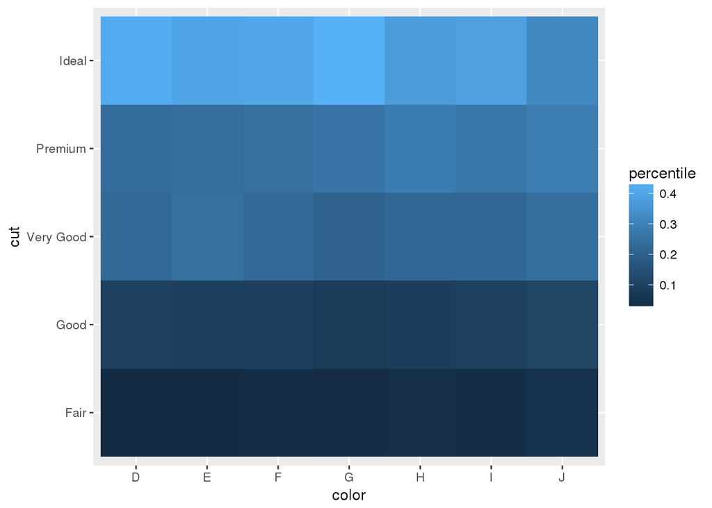

```r
diamonds %>%
  count(color, cut) %>%
  group_by(color) %>%
  mutate(percentile = n / sum(n)) %>%
  ggplot(mapping = aes(x = color, y = cut)) +
  geom_tile(mapping = aes(fill = percentile))
```

2.Use geom_tile() together with dplyr to explore how average flight delays vary by destination and month of year. What makes the plot difficult to read? How could you improve it?

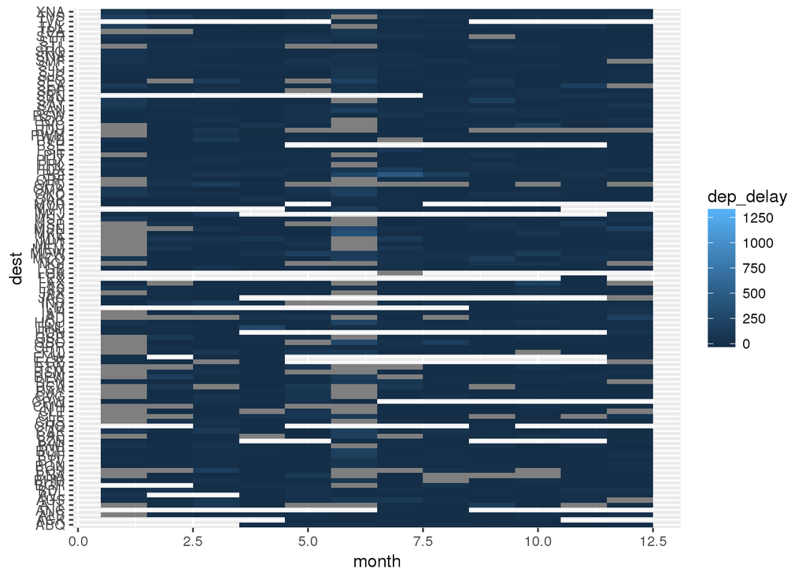

```r
#original
nycflights13::flights %>%
  ggplot(aes(x = month, y = dest)) +
  geom_tile(mapping = aes(fill = dep_delay))
```

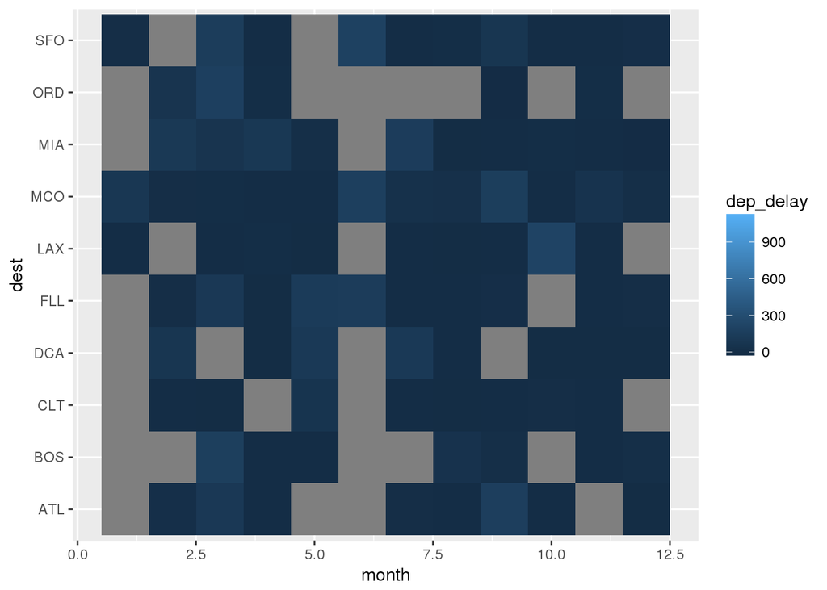

```r
#reduce the number of destinations
top_dest <- nycflights13::flights %>%
  group_by(dest) %>%
  count() %>%
  arrange(desc(n)) %>%
  .[1:10,]

nycflights13::flights %>%
  filter(dest %in% top_dest$dest) %>%
  ggplot(aes(x = month, y = dest)) +
  geom_tile(mapping = aes(fill = dep_delay))
```